# Homework_Stats_10

For each problem, unless otherwise speciﬁed, please assume that the conﬁdence level is 95%. #Problem 1

In this problem we will generate data and evaluate how well a linear model can be used to model a relationship. Don’t worry if the assumptions required to use linear regression aren’t true—even if the assumptions are false, it is still OK to use a linear model for prediction, however some of the statistical tests on the model that we will discuss in the next class will no longer be appropriate. a. Generate a vector X with 30 values, where each value is generated from a normal distribution with mean 30 and standard deviation 5. Generate a vector Y with 30 values where each value is 10 times the corresponding value in X plus a random value, generated from a normal distribution with mean 3 and standard deviation 1. Now, ﬁt a linear model. 1. What are the coeﬃcients? 2. What do you predict the Y value will be if X = 32.8? 3. What is the R2 value? b. Generate a vector X with 30 values, where each value is generated from a uniform distribution with minimum 20 and maximum 30. Generate a vector Y with 30 values where each value is 10 times the corresponding value in X plus a random value, generated from a normal distribution with mean 3 and standard deviation 1. Now, ﬁt a linear model. 1. What are the coeﬃcients? 2. What do you predict the Y value will be if X = 32.8? 3. What is the R2 value? c. Generate a vector X with 30 values, where each value is generated from a normal distribution with mean 30 and standard deviation 5. Generate a vector Y with 30 values where each value is 10 times the corresponding value in X squared, plus a random value, generated from a normal distribution with mean 3 and standard deviation 1. Now, ﬁt a linear model. 1. What are the coeﬃcients? 2. What do you predict the Y value will be if X = 32.8? 3. What is the R2 value? d. Compare the three models. Why do you think the R2 values compare as they do? Generating scatter plots may be useful.

##Problem_1.a

Generate a vector X with 30 values, where each value is generated from a normal distribution with mean 30 and standard deviation 5.

```r
set.seed(100)
x<-c(rnorm(n = 30, 30, 5))
x
```

```
 [1] 27.48904 30.65766 29.60541 34.43392 30.58486 31.59315 27.09105 33.57266 25.87370 28.20069 30.44943
[12] 30.48137 28.99183 33.69920 30.61690 29.85342 28.05573 32.55428 25.43093 41.55148 27.80955 33.82030
[23] 31.30981 33.86702 25.92810 27.80775 26.39889 31.15472 24.21135 31.23538
```

Generate a vector Y with 30 values where each value is 10 times the corresponding value in X plus a random value, generated from a normal distribution with mean 3 and standard deviation 1.

```r
z<-c(rnorm(n = 30, 3, 1))
y<-c((10*x+z))
y
```

```
 [1] 277.4901 308.8001 298.6848 348.5793 308.7411 319.1041 274.1651 338.1121 260.3078 284.6759 307.6227
[12] 308.8318 292.6627 339.6895 310.7842 300.7605 283.9813 327.9589 257.7243 416.9696 280.5768 340.9232
[23] 317.1055 341.2007 262.5789 280.6597 266.1385 315.2363 244.6533 316.7020
```

```r
reg1 = lm(y~x)
```

```r
reg1$coefficients[1]
```

[output not shown]

```r
reg1$coefficients[2]
```

[output not shown]

```r
predict(reg1,data.frame(x=32.8))
```

[output not shown]

```r
summary(reg1)
```

```
Call:
lm(formula = y ~ x)

Residuals:
    Min      1Q  Median      3Q     Max
-1.4101 -0.4744 -0.2044  0.4017  1.6825

Coefficients:
            Estimate Std. Error t value Pr(>|t|)
(Intercept)  3.24351    1.26877   2.556   0.0163 *
x            9.98985    0.04182 238.896   <2e-16 ***
---
Signif. codes:  0 ‘***’ 0.001 ‘**’ 0.01 ‘*’ 0.05 ‘.’ 0.1 ‘ ’ 1

Residual standard error: 0.7904 on 28 degrees of freedom
Multiple R-squared:  0.9995,    Adjusted R-squared:  0.9995
F-statistic: 5.707e+04 on 1 and 28 DF,  p-value: < 2.2e-16
```

```r
r1<-summary(reg1)$adj.r.squared
r1
```

```
[1] 0.9994921
```

```r
cor(y,x)
cor.test(y,x)
```

[output not shown]

##Problem_1.b

Generate a vector X with 30 values, where each value is generated from a uniform distribution with minimum 20 and maximum 30.

```r
set.seed(100)
x1<-runif(30, 20, 30)
x1
```

```
 [1] 23.07766 22.57673 25.52322 20.56383 24.68549 24.83771 28.12403 23.70321 25.46559 21.70262 26.24996
[12] 28.82166 22.80354 23.98488 27.62551 26.69022 22.04612 23.57525 23.59475 26.90291 25.35811 27.10804
[23] 25.38349 27.48972 24.20101 21.71420 27.70302 28.81954 25.49097 22.77724
```

Generate a vector Y with 30 values where each value is 10 times the corresponding value in X plus a random value, generated from a normal distribution with mean 3 and standard deviation 1.

```r
z1<-c(rnorm(n = 30, 3, 1))
y1<-c((10*x1+z1))
y1
```

```
 [1] 233.7473 228.3784 258.7431 207.7245 252.1652 250.9390 285.0043 240.2940 258.4293 219.2118 265.0612
[12] 290.4963 231.2663 241.6911 279.5022 269.8111 225.2186 238.6146 238.8363 271.3390 256.3593 274.2633
[23] 257.2522 278.9626 245.9803 220.0404 281.4334 289.4186 258.5325 230.2501
```

```r
reg2<-lm(y1~x1)
summary(reg2)
```

```
Call:
lm(formula = y1 ~ x1)

Residuals:
    Min      1Q  Median      3Q     Max
-1.9468 -0.5545 -0.1172  0.4860  2.2164

Coefficients:
            Estimate Std. Error t value Pr(>|t|)
(Intercept)  2.63919    1.82543   1.446    0.159
x1          10.01842    0.07286 137.498   <2e-16 ***
---
Signif. codes:  0 ‘***’ 0.001 ‘**’ 0.01 ‘*’ 0.05 ‘.’ 0.1 ‘ ’ 1

Residual standard error: 0.8914 on 28 degrees of freedom
Multiple R-squared:  0.9985,    Adjusted R-squared:  0.9985
F-statistic: 1.891e+04 on 1 and 28 DF,  p-value: < 2.2e-16
```

```r
reg2$coefficients[1]
```

```
(Intercept)
   2.639186
```

```r
reg2$coefficients[2]
```

```
      x1
10.01842
```

```r
predict(reg2,data.frame(x1=32.8))
```

```
       1
331.2433
```

```r
r2<-summary(reg2)$adj.r.squared
r2
```

```
[1] 0.9984683
```

```r
cor(y1,x1)
```

```
[1] 0.9992603
```

```r
cor.test(y1,x1)
```

```
    Pearson's product-moment correlation

data:  y1 and x1
t = 137.5, df = 28, p-value < 2.2e-16
alternative hypothesis: true correlation is not equal to 0
95 percent confidence interval:
 0.9984278 0.9996521
sample estimates:
      cor
0.9992603
```

##Problem_1.c

```r
y2<-(10*(x^2)+z)
y2
```

```
 [1]  7559.381  9403.676  8767.668 11859.840  9356.644  9984.050  7342.431 11274.655  6698.550  7956.759
[11]  9274.577  9295.544  8406.485 11359.985  9376.422  8916.587  7873.876 10602.131  6470.365 17266.380
[21]  7736.264 11439.390  9806.219 11474.650  6723.394  7736.688  6970.616  9710.992  5866.277  9758.651
```

```r
reg3<-lm(y2~x)
reg3
```

```
Call:
lm(formula = y2 ~ x)

Coefficients:
(Intercept)            x
    -9943.6        635.4
```

```r
summary(reg3)
```

```
Call:
lm(formula = y2 ~ x)

Residuals:
    Min      1Q  Median      3Q     Max
-145.45 -130.65  -99.24   31.18  809.73

Coefficients:
            Estimate Std. Error t value Pr(>|t|)
(Intercept) -9943.58     342.23  -29.06   <2e-16 ***
x             635.36      11.28   56.33   <2e-16 ***
---
Signif. codes:  0 ‘***’ 0.001 ‘**’ 0.01 ‘*’ 0.05 ‘.’ 0.1 ‘ ’ 1

Residual standard error: 213.2 on 28 degrees of freedom
Multiple R-squared:  0.9913,    Adjusted R-squared:  0.9909
F-statistic:  3173 on 1 and 28 DF,  p-value: < 2.2e-16
```

```r
fitted(reg3)
```

```
        1         2         3         4         5         6         7         8         9        10
 7521.907  9535.126  8866.572 11934.422  9488.872 10129.503  7269.038 11387.210  6495.584  7974.063
       11        12        13        14        15        16        17        18        19        20
 9402.827  9423.122  8476.724 11467.608  9509.229  9024.143  7881.960 10740.169  6214.263 16456.649
       21        22        23        24        25        26        27        28        29        30
 7725.548 11544.551  9949.477 11574.235  6530.149  7724.402  6829.270  9850.943  5439.391  9902.190
```

```r
reg3$coefficients[1]
```

```
(Intercept)
   -9943.58
```

```r
reg3$coefficients[2]
```

```
       x
635.3619
```

```r
predict(reg3,data.frame(x=32.8))
```

```
       1
10896.29
```

```r
r3<-summary(reg3)$adj.r.squared
r3
```

```
[1] 0.9909406
```

```r
cor(y2,x)
```

```
[1] 0.9956169
```

```r
cor.test(y2,x)
```

```
    Pearson's product-moment correlation

data:  y2 and x
t = 56.33, df = 28, p-value < 2.2e-16
alternative hypothesis: true correlation is not equal to 0
95 percent confidence interval:
 0.9907031 0.9979362
sample estimates:
      cor
0.9956169
```

##Problem_1.d

```r
Rsq<-c(r1,r2,r3)
Rsq
```

```
[1] 0.9994921 0.9984683 0.9909406
```

When a scatterplot between the response and a predictor shows a non-linear relationship where the residuals are reasonably normal in distribution, appropriate transformations on the predictor may linearize the relationship between the variables without drastically altering the distribution of the residuals. After the transformation of the predictor(s), the residuals produced with the transformed variable(s) in the new model will need to be reanalyzed to assure normality assumptions are still satisfied.

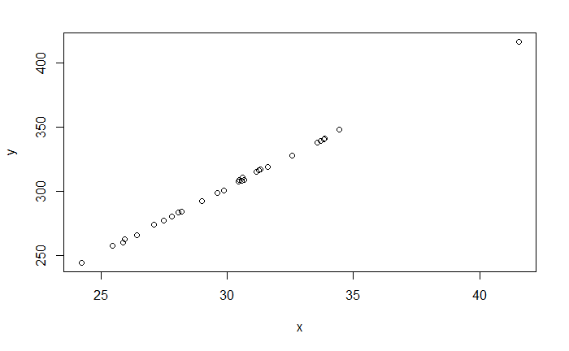

```r
plot(y~x)
```

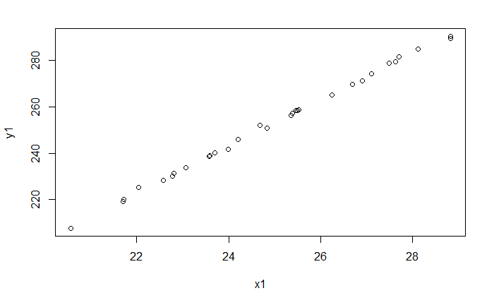

```r
plot(y1~x1)
```

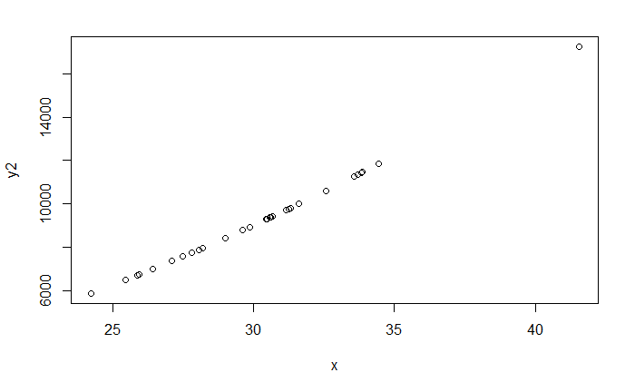

```r
plot(y2~x)
```

Scatterplots of residuals versus a time, sequence, or order variable can often detect non-independence of error terms.

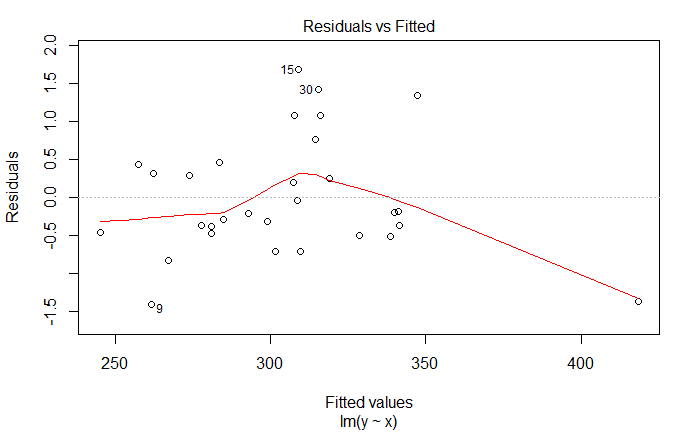

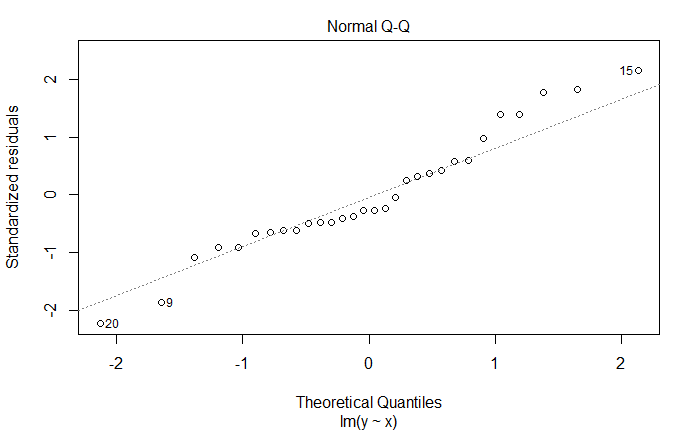

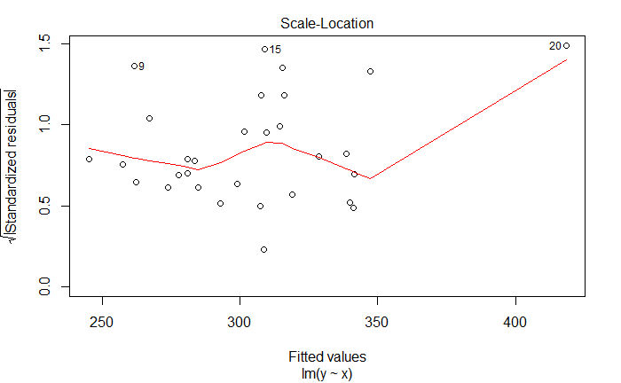

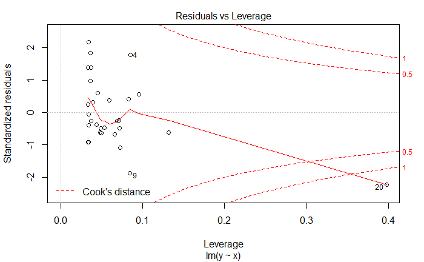

```r
plot(reg1)
```

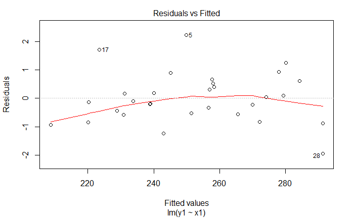

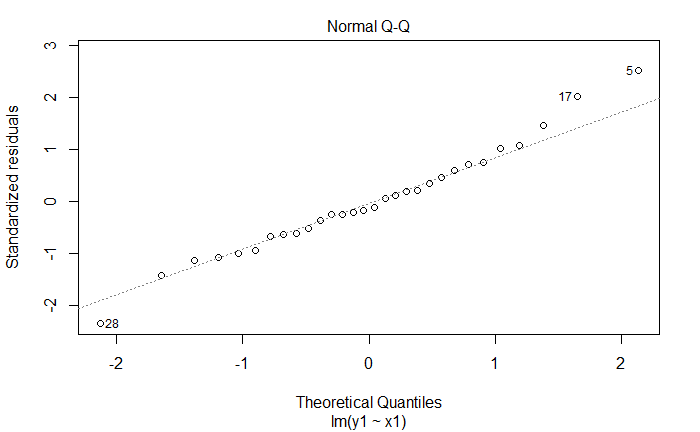

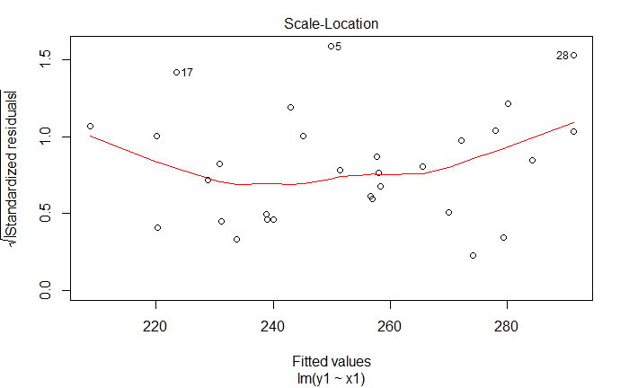

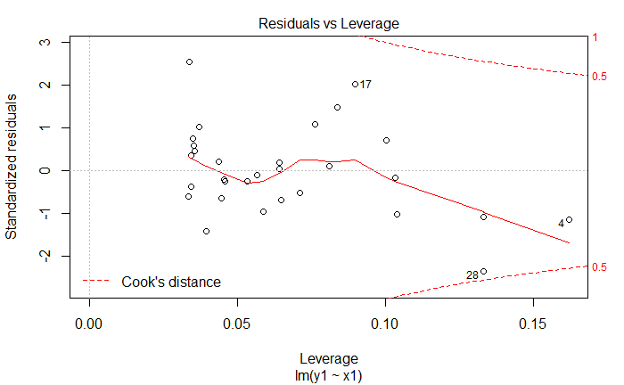

```r
plot(reg2)
```

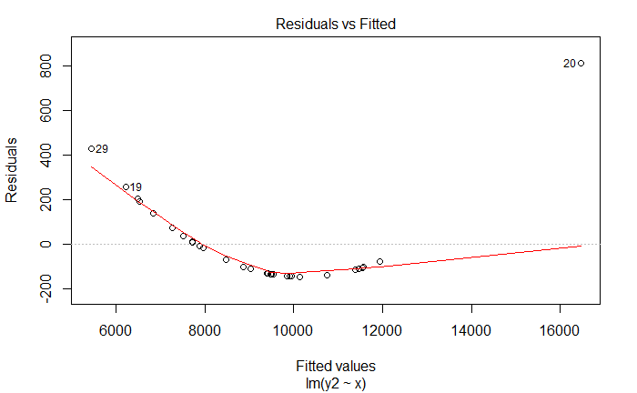

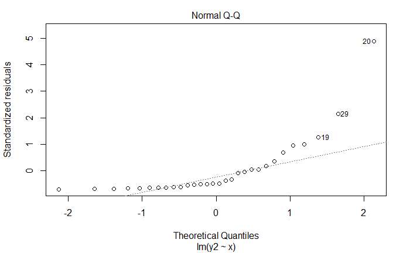

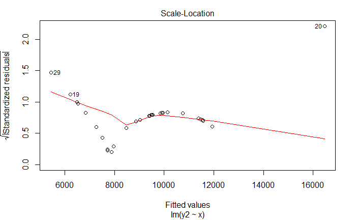

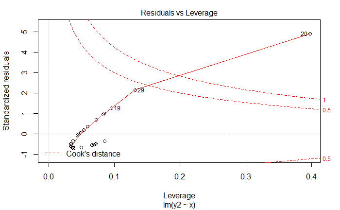

```r
plot(reg3)
```

#Problem_2

Consider the data set mtcars which is available in base R. a. Build a linear regression model predicting mpg using hp. b. What is the regression equation? c. What would you predict the mpg of a car to be if hp is 110 using the regression equation? d. Run a statistical test to determine if there is a linear relationship between hp and mpg. Formally write the null and alternative hypotheses. What is the p-value of the test? e. As brieﬂy mentioned in class, there is a statistical test that can be run for the correlation between two variables. If you have variable X and variable Y , the null hypothesis is that there is no correlation between the two variables, and the alternative hypothesis is that there is non-zero correlation between the two variables. The command is cor.test which takes two arguments, that are the variables you are testing for correlation. Before running the test, what is the correlation between hp and mpg? f. Run a statistical test to determine if there is correlation between the two variables using cor.test(mtcars$mpg,mtcars$hp). This has various outputs. What is the conﬁdence interval? Note: This represents a 95% conﬁdence interval for the correlation between the two variables. g. What is the p-value for the statistical test in the previous part? Do you reject the null hypothesis? h. In part d. you found a p-value for whether or not there is a statistically signiﬁcant linear relationship between hp and mpg, and you found a p-value. How does that p-value compare with the p-value found in part g.? Explain the relationship. i. There are other variables in the data set. Try adding some variables to the regression model. Do any result in a better adjusted r2? What is the best collection of variables that you can identify for predicting mpg that has the highest adjusted r2?

##Problem_2a

```r
reg4 <- lm( mtcars$mpg ~ mtcars$hp )
reg4
```

```
Call:
lm(formula = mtcars$mpg ~ mtcars$hp)

Coefficients:
(Intercept)    mtcars$hp
   30.09886     -0.06823
```

##Problem_2b

The estimated regression function is Yi` = 30.1 - 0.07xi or mpg = 30.1 - 0.07*hp

```r
reg4$coefficients[1]
```

```
(Intercept)
   30.09886
```

```r
reg4$coefficients[2]
```

```
  mtcars$hp
-0.06822828
```

```r
mtcars$hp*reg4$coefficients[2]+reg4$coefficients[1]
```

```
 [1] 22.593750 22.593750 23.753631 22.593750 18.158912 22.934891 13.382932 25.868707 23.617174 21.706782
[11] 21.706782 17.817770 17.817770 17.817770 16.112064 15.429781 14.406357 25.595794 26.550990 25.664022
[21] 23.480718 19.864619 19.864619 13.382932 18.158912 25.595794 23.890087 22.389065 12.086595 18.158912
[31]  7.242387 22.661978
```

mpg = 30.1 - 0.07*hp

```r
summary(reg4)$coef # lm coefficients)
```

```
               Estimate Std. Error   t value     Pr(>|t|)
(Intercept) 30.09886054  1.6339210 18.421246 6.642736e-18
mtcars$hp   -0.06822828  0.0101193 -6.742389 1.787835e-07
```

```r
confint(reg4, level = 0.95)
```

```
                  2.5 %     97.5 %
(Intercept) 26.76194879 33.4357723
mtcars$hp   -0.08889465 -0.0475619
```

```r
summary(reg4)
```

```
Call:
lm(formula = mtcars$mpg ~ mtcars$hp)

Residuals:
    Min      1Q  Median      3Q     Max
-5.7121 -2.1122 -0.8854  1.5819  8.2360

Coefficients:
            Estimate Std. Error t value Pr(>|t|)
(Intercept) 30.09886    1.63392  18.421  < 2e-16 ***
mtcars$hp   -0.06823    0.01012  -6.742 1.79e-07 ***
---
Signif. codes:  0 ‘***’ 0.001 ‘**’ 0.01 ‘*’ 0.05 ‘.’ 0.1 ‘ ’ 1

Residual standard error: 3.863 on 30 degrees of freedom
Multiple R-squared:  0.6024,    Adjusted R-squared:  0.5892
F-statistic: 45.46 on 1 and 30 DF,  p-value: 1.788e-07
```

##Problem_2e

the null hypothesis is that there is no correlation between the two variables the alternative hypothesis is that there is non-zero correlation between the two variables.

```r
cor(mtcars$mpg,mtcars$hp)
```

```
[1] -0.7761684
```

##Problem_2f

```r
cor.test(mtcars$mpg,mtcars$hp)
```

```
    Pearson's product-moment correlation

data:  mtcars$mpg and mtcars$hp
t = -6.7424, df = 30, p-value = 1.788e-07
alternative hypothesis: true correlation is not equal to 0
95 percent confidence interval:
 -0.8852686 -0.5860994
sample estimates:
       cor
-0.7761684
```

95 percent confidence interval: -0.8852686 -0.5860994

##Problem_2g

p-value = 1.788e-07

##Problem_2h

Both the p-values are the same and are equal to p-value = 1.788e-07. The p-values help determine whether the relationships that you observe in your sample also exist in the larger population. In this question, we have two different cases where one talks about linearity whereas other talks about correlation. For linearity, there must be a correlation between the predictor and the response. So, if we rejected the null hypothesis that there is no linearity then we also in turn approved that there is a correlation between the variables. In a nutshell, both the p-values are pointing to similar conditions.

Note: The p-value for each independent variable tests the null hypothesis that the variable has no correlation with the dependent variable. If there is no correlation, there is no association between the changes in the independent variable and the shifts in the dependent variable. In other words, there is insufficient evidence to conclude that there is effect at the population level. If the p-value for a variable is less than your significance level, your sample data provide enough evidence to reject the null hypothesis for the entire population. Your data favor the hypothesis that there is a non-zero correlation. Changes in the independent variable are associated with changes in the response at the population level. This variable is statistically significant and probably a worthwhile addition to your regression model.

##Problem_2i

We notice that cyl,vs, am,gear,& carb are categorical variables.We also have to look out for multi-collinearity to robust our regression model

```r
reg5 <- lm(mtcars$mpg~mtcars$wt + mtcars$hp)
p1<-summary(reg5)$adj.r.squared
reg6 <- lm(mtcars$mpg~mtcars$wt + mtcars$hp+mtcars$disp)
p2<-summary(reg6)$adj.r.squared
reg7 <- lm(mtcars$mpg~mtcars$wt + mtcars$hp+mtcars$disp+mtcars$drat)
p3<-summary(reg7)$adj.r.squared
reg8 <- lm(mtcars$mpg~mtcars$wt + mtcars$hp+mtcars$disp+mtcars$qsec)
p4<-summary(reg8)$adj.r.squared
reg9 <- lm(mtcars$mpg~mtcars$wt + mtcars$hp+mtcars$qsec+mtcars$drat)
p5<-summary(reg9)$adj.r.squared
z10<-c(p1,p2,p3,p4,p5)
z10
```

```
[1] 0.8148396 0.8082829 0.8135739 0.8107212 0.8224794
```

```r
reg10 <- lm(mtcars$mpg~mtcars$wt + mtcars$hp+mtcars$cyl)
p6<-summary(reg10)$adj.r.squared
p6
```

```
[1] 0.8263446
```

but if we include categorical variable cylinder after much inspection we get that it provides the highest r-squared value then.